# STAT 757 Assignment 10

DUE 5/06/2018 11:59PM

AG Schissler

2/14/2018

## Instructions [20 points]

Modify this file to provide responses to the Ch.10 Exercises in Sheather (2009). You can find some helpful code here: [http://www.stat. tamu.edu/~sheather/book/docs/rcode/Chapter10.R](http://www.stat.tamu.edu/~sheather/book/docs/rcode/Chapter10.R). Also address the project milestones indicated below. Please email **both** your .Rmd (or roxygen .R) and one of the following either .HTML, .PDF, or .DOCX using the format SURNAME-FIRSTNAME-Assignment10.Rmd and SURNAME-FIRSTNAME-Assignment10.pdf.

## Exercise 10.3.4 [60 points]

```r
myDir <- "~/OneDrive - University of Nevada, Reno/Teaching/STAT_757/Sheather_data/Data/"
dat <- read.table(file.path(myDir,"sleepstudy.txt"), header = T)
str(dat)
attach(dat)
library(nlme)
```

### Part A

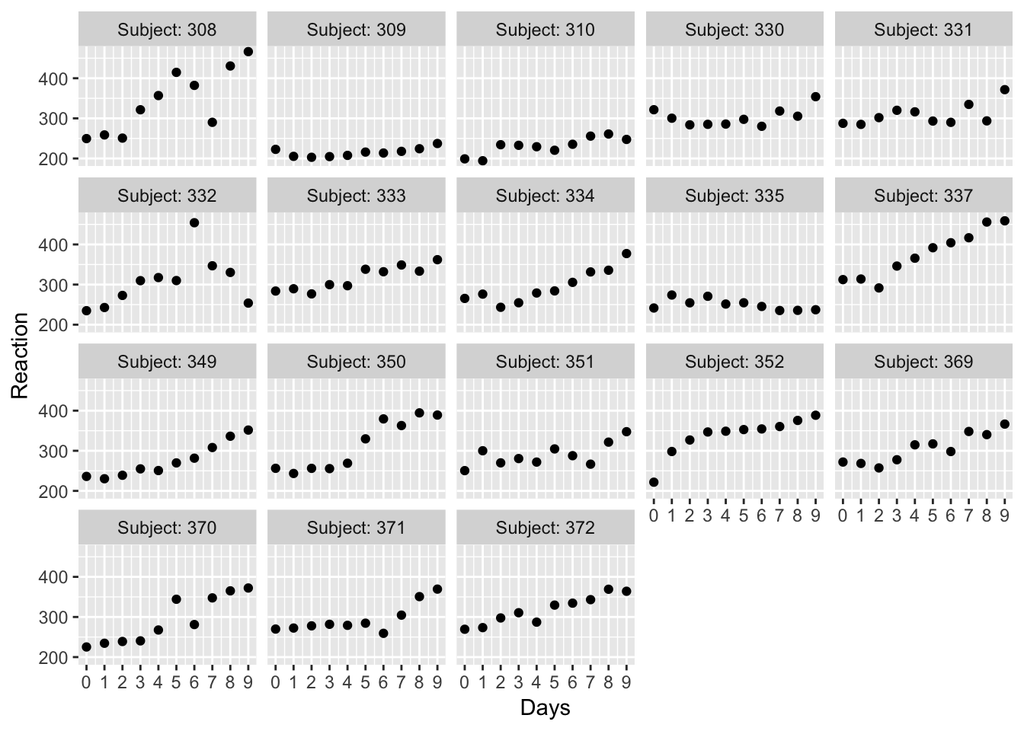

```r
ggplot(dat, aes(x=Days, y=Reaction)) +
    geom_point() +
    scale_x_continuous(breaks=0:9) +
    facet_wrap("Subject", labeller = label_both)
```

```r
wide_data <- t( do.call( "rbind", split(Reaction, Days) ) )
cor(wide_data)
```

```
##         0       1       2       3       4       5       6       7       8
## 0 1.00000 0.73672 0.46982 0.46369 0.44886 0.37196 0.22178 0.49287 0.32908
## 1 0.73672 1.00000 0.77042 0.74146 0.65100 0.52899 0.31496 0.47622 0.39517
## 2 0.46982 0.77042 1.00000 0.87507 0.69401 0.49212 0.45433 0.59033 0.40637
## 3 0.46369 0.74146 0.87507 1.00000 0.91369 0.72206 0.67482 0.59955 0.59584
## 4 0.44886 0.65100 0.69401 0.91369 1.00000 0.85412 0.74931 0.69489 0.74457
## 5 0.37196 0.52899 0.49212 0.72206 0.85412 1.00000 0.74318 0.69031 0.90097
## 6 0.22178 0.31496 0.45433 0.67482 0.74931 0.74318 1.00000 0.70345 0.72871
## 7 0.49287 0.47622 0.59033 0.59955 0.69489 0.69031 0.70345 1.00000 0.76169
## 8 0.32908 0.39517 0.40637 0.59584 0.74457 0.90097 0.72871 0.76169 1.00000
## 9 0.51574 0.54650 0.42325 0.56571 0.71558 0.83771 0.46012 0.65868 0.88139
##         9
## 0 0.51574
## 1 0.54650
## 2 0.42325
## 3 0.56571
## 4 0.71558
## 5 0.83771
## 6 0.46012
## 7 0.65868
## 8 0.88139
## 9 1.00000
```

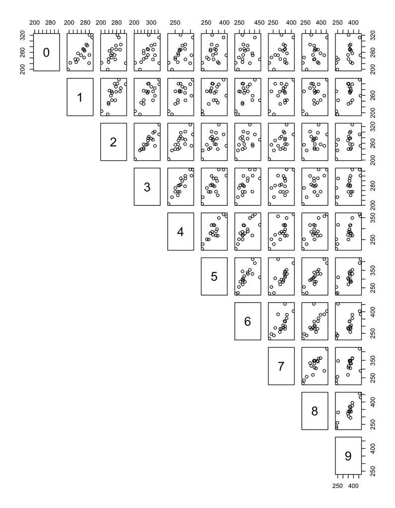

```r
pairs(~ ., data = wide_data, lower.panel=NULL)
```

It appears that conditional mean structure varies by subject, both in terms of random intercepts and slopes. Moreover, there appears to be periods within each subject with differing slopes, suggesting a spline modeling approach. The error covariance is not constant and as such a simple random intercept model is not sufficient (i.e., assuming constant correlation between any two time points). There are unusual data points for Subject 308, 332.

### Part B (unstructured covariance)

We fit model (10.17) from page 369 using the following code:

```r
m1 <- nlme::gls( Reaction~Days, data=dat,
 correlation=corSymm(form=~1|Subject), weights=varIdent(form=~1|Days),method="REML")
summary(m1)
```

```
## Generalized least squares fit by REML
##   Model: Reaction ~ Days
##   Data: dat
##      AIC    BIC logLik
##   1730.2 1911.6 -808.1
##
## Correlation Structure: General
##  Formula: ~1 | Subject
##  Parameter estimate(s):
##  Correlation:
##    1     2     3     4     5     6     7     8     9
## 2  0.791
## 3  0.508 0.773
## 4  0.550 0.778 0.878
## 5  0.493 0.672 0.715 0.915
## 6  0.480 0.603 0.533 0.760 0.860
## 7  0.294 0.373 0.488 0.696 0.765 0.757
## 8  0.515 0.509 0.616 0.627 0.715 0.708 0.721
## 9  0.416 0.469 0.453 0.641 0.764 0.910 0.748 0.778
## 10 0.579 0.605 0.469 0.619 0.738 0.858 0.503 0.684 0.895
## Variance function:
##  Structure: Different standard deviations per stratum
##  Formula: ~1 | Days
##  Parameter estimates:
##       0       1       2       3       4       5       6       7       8
## 1.00000 1.00566 0.82826 1.13001 1.19541 1.51400 1.76345 1.40779 1.72453
##       9
## 1.93641
##
## Coefficients:
##               Value Std.Error t-value p-value
## (Intercept) 239.469    4.3606  54.917       0
## Days         10.018    1.1202   8.943       0
##
##  Correlation:
##      (Intr)
## Days 0.29
##
## Standardized residuals:
##      Min       Q1      Med       Q3      Max
## -1.90082 -0.29590  0.32515  0.85492  2.44140
##
## Residual standard error: 35.905
## Degrees of freedom: 180 total; 178 residual
```

```r
coef(m1)
```

```
## (Intercept)        Days
##     239.469      10.018
```

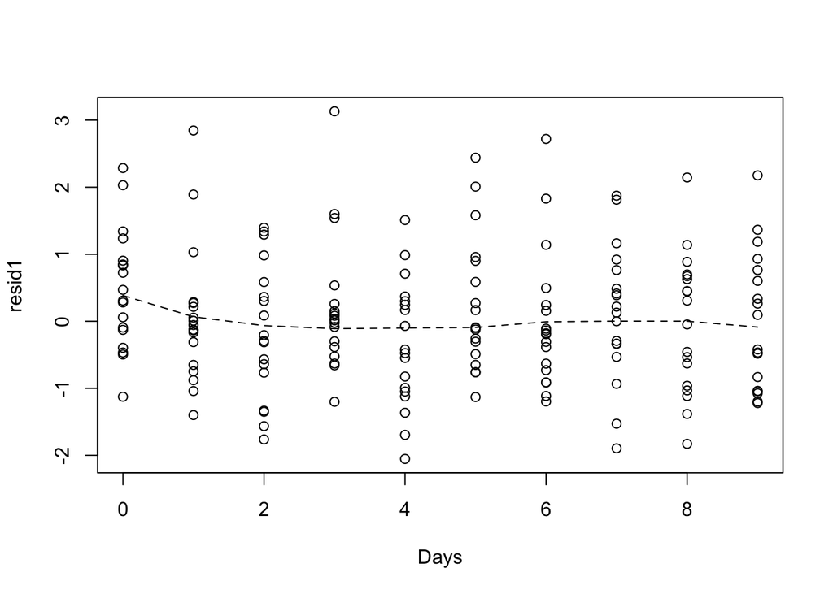

```r
resid1 <- residuals( m1, type="normalized" )
plot( Days, resid1 )
lines( lowess( Days, resid1, iter=1, f=1/3 ), lty=2 )
```

No pattern evident here.

### Part C (random intercepts and slopes)

```r
m2 <- nlme::lme( Reaction~Days, data=dat, random= ~ 1 + Days |Subject, weights=varIdent(form=~1|Days), method="REML" )
summary(m2)
```

```
## Linear mixed-effects model fit by REML
##  Data: dat
##    AIC    BIC  logLik
##   1742 1789.7 -855.99
##
## Random effects:
##  Formula: ~1 + Days | Subject
##  Structure: General positive-definite, Log-Cholesky parametrization
##             StdDev  Corr
## (Intercept) 29.8563 (Intr)
## Days         7.0495 -0.231
## Residual    27.3803
##
## Variance function:
##  Structure: Different standard deviations per stratum
##  Formula: ~1 | Days
##  Parameter estimates:
##       0       1       2       3       4       5       6       7       8
## 1.00000 0.58585 0.62218 0.57657 0.61761 0.76528 1.43922 1.17776 0.56804
##       9
## 1.22062
## Fixed effects: Reaction ~ Days
##               Value Std.Error  DF t-value p-value
## (Intercept) 250.474    7.5325 161  33.252       0
## Days         10.625    1.7539 161   6.058       0
##  Correlation:
##      (Intr)
## Days -0.3
##
## Standardized Within-Group Residuals:
##       Min        Q1       Med        Q3       Max
## -3.529341 -0.480984 -0.022732  0.555028  3.436921
##
## Number of Observations: 180
## Number of Groups: 18
```

```r
coef(m2)
```

```
##     (Intercept)    Days
## 308      243.68 22.8979
## 309      204.87  2.4455
## 310      206.98  6.2893
## 330      281.97  3.5854
## 331      287.82  3.8852
## 332      256.21 10.4197
## 333      271.31  8.9304
## 334      240.72 11.2492
## 335      263.69 -2.3523
## 337      281.87 20.3939
## 349      216.83 13.2807
## 350      220.77 19.4795
## 351      264.26  6.4208
## 352      286.34 12.4416
## 369      252.50 11.5415
## 370      211.94 17.9918
## 371      253.11 10.2041
## 372      263.67 12.1516
```

Notice how the estimated error variance increases slightly with time.

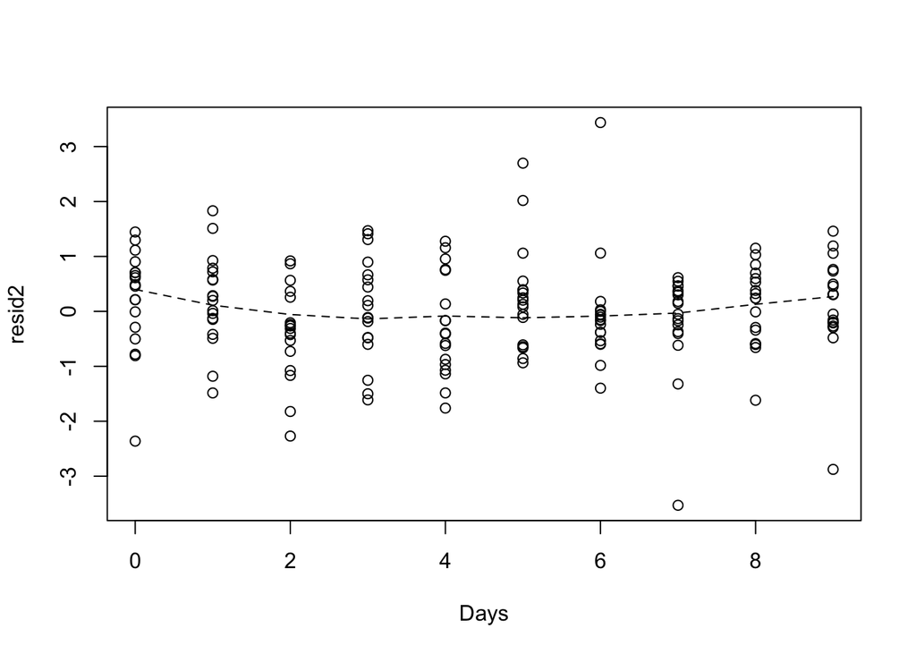

```r
resid2 <- residuals( m2, type="normalized" )
plot( Days, resid2 )
lines( lowess( Days, resid2, iter=1, f=1/3 ), lty=2 )
```

No pattern evident here.

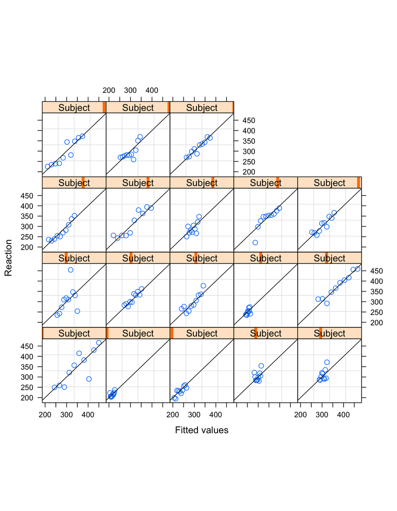

```r
plot(m2, form = Reaction ~ fitted(.) | Subject,layout = c(5,4), aspect = 1.0, abline = c(0,1))
```

### Part D (random intercepts)

```r
m3 <- nlme::lme( Reaction~Days, data=dat, random=~1|Subject, weights=varIdent(form=~1|Days), method="REML" )
summary(m3)
```

```
## Linear mixed-effects model fit by REML
##  Data: dat
##      AIC  BIC  logLik
##   1781.6 1823 -877.79
##
## Random effects:
##  Formula: ~1 | Subject
##         (Intercept) Residual
## StdDev:      34.876   31.824
##
## Variance function:
##  Structure: Different standard deviations per stratum
##  Formula: ~1 | Days
##  Parameter estimates:
##       0       1       2       3       4       5       6       7       8
## 1.00000 0.74845 0.66955 0.42925 0.47934 0.93298 1.37318 1.04807 1.27699
##       9
## 1.49933
## Fixed effects: Reaction ~ Days
##               Value Std.Error  DF t-value p-value
## (Intercept) 250.855    8.9358 161  28.073       0
## Days         10.275    0.8732 161  11.767       0
##  Correlation:
##      (Intr)
## Days -0.34
##
## Standardized Within-Group Residuals:
##       Min        Q1       Med        Q3       Max
## -2.665609 -0.496555  0.056493  0.583909  2.906008
##
## Number of Observations: 180
## Number of Groups: 18
```

```r
coef(m3)
```

```
##     (Intercept)   Days
## 308      287.05 10.275
## 309      176.88 10.275
## 310      195.13 10.275
## 330      257.17 10.275
## 331      273.63 10.275
## 332      265.52 10.275
## 333      266.45 10.275
## 334      239.26 10.275
## 335      223.04 10.275
## 337      314.94 10.275
## 349      223.45 10.275
## 350      243.56 10.275
## 351      245.96 10.275
## 352      298.71 10.275
## 369      257.48 10.275
## 370      230.68 10.275
## 371      248.58 10.275
## 372      267.89 10.275
```

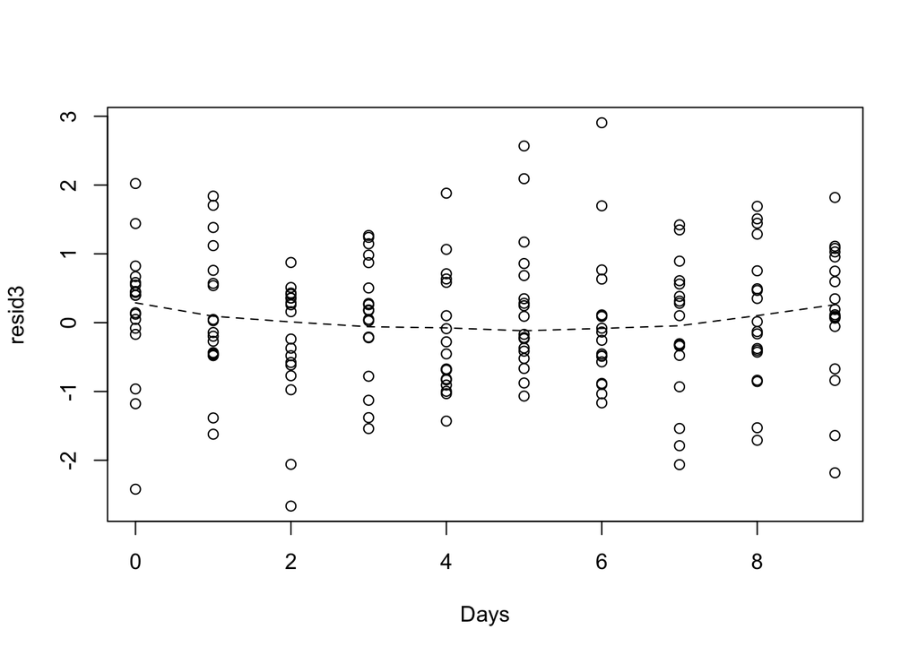

```r
resid3 <- residuals( m3, type="normalized" )
plot( Days, resid3 )
lines( lowess( Days, resid3, iter=1, f=1/3 ), lty=2 )
```

No pattern evident here.

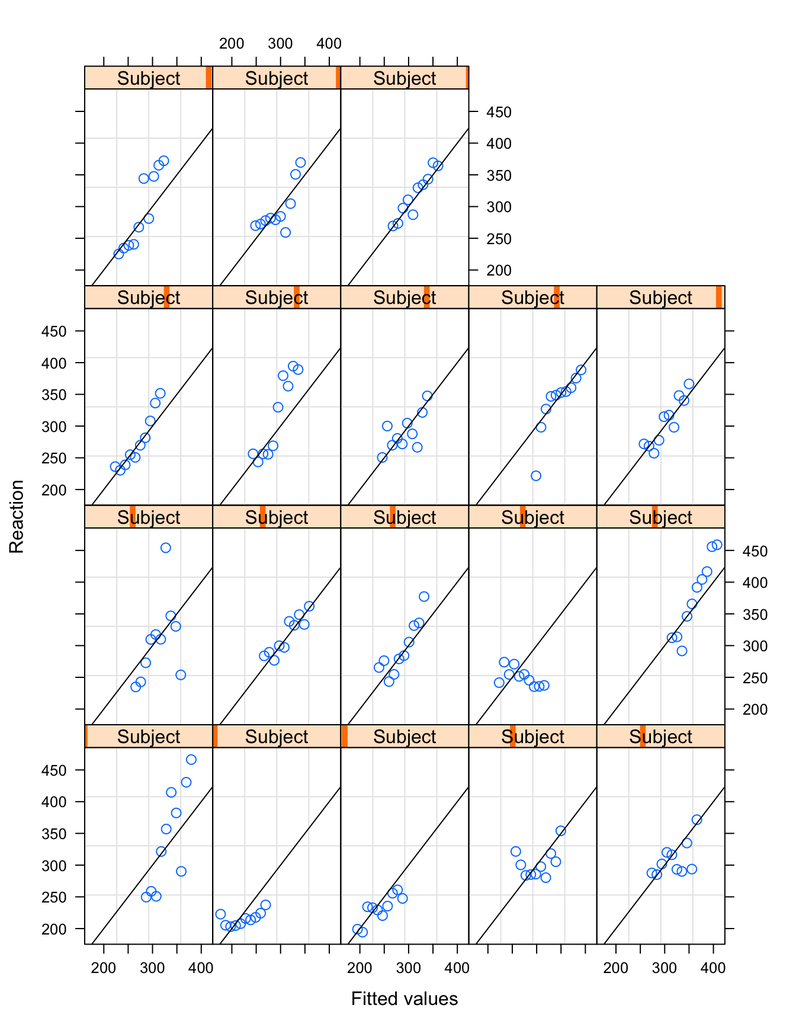

```r
plot(m3, form = Reaction ~ fitted(.) | Subject ,layout = c(5,4), abline = c(0,1))
```

### Part D

```r
anova(m1,m2,m3)
```

```
##    Model df    AIC    BIC  logLik   Test L.Ratio p-value
## m1     1 57 1730.2 1911.6 -808.10
## m2     2 15 1742.0 1789.7 -855.99 1 vs 2  95.780  <.0001
## m3     3 13 1781.6 1823.0 -877.79 2 vs 3  43.615  <.0001
```

### Part E

Add the step functions.

```r
dat$DaysM1Plus <- Days - 1
dat$DaysM1Plus[dat$DaysM1Plus < 0] <- 0
dat$DaysM2Plus <- Days - 2
dat$DaysM2Plus[dat$DaysM2Plus < 0] <- 0
dat$DaysM3Plus <- Days - 3
dat$DaysM3Plus[dat$DaysM3Plus < 0] <- 0
dat$DaysM4Plus <- Days - 4
dat$DaysM4Plus[dat$DaysM4Plus < 0] <- 0
dat$DaysM5Plus <- Days - 5
dat$DaysM5Plus[dat$DaysM5Plus < 0] <- 0
dat$DaysM6Plus <- Days - 6
dat$DaysM6Plus[dat$DaysM6Plus < 0] <- 0
dat$DaysM7Plus <- Days - 7
dat$DaysM7Plus[dat$DaysM7Plus < 0] <- 0
dat$DaysM8Plus <- Days - 8
dat$DaysM8Plus[dat$DaysM8Plus < 0] <- 0
```

```r
m4 <- nlme::gls(Reaction~Days+DaysM1Plus+DaysM2Plus+DaysM3Plus+DaysM4Plus+DaysM5Plus+DaysM6Plus+DaysM7Plus+DaysM8Plus,
data=dat,correlation=corSymm(form=~1|Subject),weights=varIdent(form=~1|Days),method="REML")
summary(m4)
```

```
## Generalized least squares fit by REML
##   Model: Reaction ~ Days + DaysM1Plus + DaysM2Plus + DaysM3Plus + DaysM4Plus +      DaysM5Plus + DaysM6Plus + DaysM7Plus + DaysM8Plus
##   Data: dat
##      AIC    BIC  logLik
##   1689.9 1893.8 -779.97
##
## Correlation Structure: General
##  Formula: ~1 | Subject
##  Parameter estimate(s):
##  Correlation:
##    1     2     3     4     5     6     7     8     9
## 2  0.737
## 3  0.470 0.770
## 4  0.464 0.741 0.875
## 5  0.449 0.651 0.694 0.914
## 6  0.372 0.529 0.492 0.722 0.854
## 7  0.222 0.315 0.454 0.675 0.749 0.743
## 8  0.493 0.476 0.590 0.600 0.695 0.690 0.703
## 9  0.329 0.395 0.406 0.596 0.745 0.901 0.729 0.762
## 10 0.516 0.546 0.423 0.566 0.716 0.838 0.460 0.659 0.881
## Variance function:
##  Structure: Different standard deviations per stratum
##  Formula: ~1 | Days
##  Parameter estimates:
##       0       1       2       3       4       5       6       7       8
## 1.00000 1.04047 0.91732 1.20939 1.32392 1.61126 1.96619 1.55941 1.87363
##       9
## 2.08485
##
## Coefficients:
##               Value Std.Error t-value p-value
## (Intercept) 256.652    7.5730  33.890  0.0000
## Days          7.844    5.6139   1.397  0.1642
## DaysM1Plus   -6.978    7.6722  -0.909  0.3644
## DaysM2Plus   16.764    7.3914   2.268  0.0246
## DaysM3Plus  -11.973    4.7626  -2.514  0.0129
## DaysM4Plus   14.212    6.5333   2.175  0.0310
## DaysM5Plus  -16.209   13.5444  -1.197  0.2331
## DaysM6Plus    2.913   18.4190   0.158  0.8745
## DaysM7Plus   11.307   16.8373   0.672  0.5028
## DaysM8Plus   -3.657   11.8044  -0.310  0.7571
##
##  Correlation:
##            (Intr) Days   DysM1P DysM2P DysM3P DysM4P DysM5P DysM6P DysM7P
## Days       -0.315
## DaysM1Plus -0.101 -0.747
## DaysM2Plus  0.477  0.110 -0.608
## DaysM3Plus -0.153 -0.295  0.179 -0.344
## DaysM4Plus -0.033  0.086 -0.078 -0.065 -0.176
## DaysM5Plus -0.094 -0.048  0.278 -0.226 -0.214 -0.571
## DaysM6Plus  0.204 -0.069 -0.127 -0.070  0.413  0.114 -0.715
## DaysM7Plus -0.218  0.215 -0.175  0.417 -0.450  0.231 -0.012 -0.619
## DaysM8Plus  0.392 -0.167  0.021 -0.158  0.264 -0.347  0.062  0.497 -0.843
##
## Standardized residuals:
##        Min         Q1        Med         Q3        Max
## -2.1166509 -0.6418273  0.0030278  0.6037484  2.2475461
##
## Residual standard error: 32.129
## Degrees of freedom: 180 total; 170 residual
```

Different fixed effects! So to compare models use ML not REML.

```r
m5 <- nlme::gls(Reaction~Days+DaysM1Plus+DaysM2Plus+DaysM3Plus+DaysM4Plus+DaysM5Plus+DaysM6Plus+DaysM7Plus+DaysM8Plus,
                data=dat,correlation=corSymm(form=~1|Subject),weights=varIdent(form=~1|Days),method="ML")
m6 <- nlme::gls(Reaction~Days, data=dat,correlation=corSymm(form=~1|Subject),weights=varIdent(form=~1|Days),method="ML")
anova(m5,m6)
```

```
##    Model df    AIC    BIC  logLik   Test L.Ratio p-value
## m5     1 65 1740.8 1948.3 -805.40
## m6     2 57 1736.9 1918.9 -811.45 1 vs 2  12.099  0.1468
```

Hmm, I did not reproduce the result that the new spline-based model is better. In fact, Days is no longer significant.

Nonetheless, I will proceed with finding a reduced spline model.

```r
summary(m5)
```

```
## Generalized least squares fit by maximum likelihood
##   Model: Reaction ~ Days + DaysM1Plus + DaysM2Plus + DaysM3Plus + DaysM4Plus +      DaysM5Plus + DaysM6Plus + DaysM7Plus + DaysM8Plus
##   Data: dat
##      AIC    BIC logLik
##   1740.8 1948.3 -805.4
##
## Correlation Structure: General
##  Formula: ~1 | Subject
##  Parameter estimate(s):
##  Correlation:
##    1     2     3     4     5     6     7     8     9
## 2  0.737
## 3  0.470 0.770
## 4  0.464 0.741 0.875
## 5  0.449 0.651 0.694 0.914
## 6  0.372 0.529 0.492 0.722 0.854
## 7  0.222 0.315 0.454 0.675 0.749 0.743
## 8  0.493 0.476 0.590 0.600 0.695 0.690 0.703
## 9  0.329 0.395 0.406 0.596 0.745 0.901 0.729 0.762
## 10 0.516 0.546 0.423 0.566 0.716 0.838 0.460 0.659 0.881
## Variance function:
##  Structure: Different standard deviations per stratum
##  Formula: ~1 | Days
##  Parameter estimates:
##       0       1       2       3       4       5       6       7       8
## 1.00000 1.04049 0.91733 1.20941 1.32395 1.61128 1.96623 1.55944 1.87366
##       9
## 2.08488
##
## Coefficients:
##               Value Std.Error t-value p-value
## (Intercept) 256.652    7.5730  33.890  0.0000
## Days          7.844    5.6139   1.397  0.1642
## DaysM1Plus   -6.978    7.6722  -0.909  0.3644
## DaysM2Plus   16.764    7.3915   2.268  0.0246
## DaysM3Plus  -11.973    4.7625  -2.514  0.0129
## DaysM4Plus   14.212    6.5333   2.175  0.0310
## DaysM5Plus  -16.209   13.5444  -1.197  0.2331
## DaysM6Plus    2.913   18.4191   0.158  0.8745
## DaysM7Plus   11.307   16.8374   0.672  0.5028
## DaysM8Plus   -3.657   11.8044  -0.310  0.7571
##
##  Correlation:
##            (Intr) Days   DysM1P DysM2P DysM3P DysM4P DysM5P DysM6P DysM7P
## Days       -0.315
## DaysM1Plus -0.101 -0.747
## DaysM2Plus  0.477  0.110 -0.608
## DaysM3Plus -0.153 -0.295  0.179 -0.344
## DaysM4Plus -0.033  0.086 -0.078 -0.065 -0.176
## DaysM5Plus -0.094 -0.048  0.278 -0.226 -0.214 -0.571
## DaysM6Plus  0.204 -0.069 -0.127 -0.070  0.413  0.114 -0.715
## DaysM7Plus -0.218  0.215 -0.175  0.417 -0.450  0.231 -0.012 -0.619
## DaysM8Plus  0.392 -0.167  0.021 -0.158  0.264 -0.347  0.062  0.497 -0.843
##
## Standardized residuals:
##        Min         Q1        Med         Q3        Max
## -2.1779870 -0.6604318  0.0031156  0.6212425  2.3126626
##
## Residual standard error: 31.224
## Degrees of freedom: 180 total; 170 residual
```

Inspecting the (unadjusted) p-values for the step functions, we see that DaysM2Plus, DaysM3Plus, and DaysM4Plus are significant. Let’s remove all others and compare the ML estimates.

```r
m7 <- nlme::gls(Reaction~Days+DaysM2Plus+DaysM3Plus+DaysM4Plus,
                data=dat,correlation=corSymm(form=~1|Subject),weights=varIdent(form=~1|Days),method="ML")
summary(m7)
```

```
## Generalized least squares fit by maximum likelihood
##   Model: Reaction ~ Days + DaysM2Plus + DaysM3Plus + DaysM4Plus
##   Data: dat
##    AIC    BIC  logLik
##   1734 1925.6 -807.02
##
## Correlation Structure: General
##  Formula: ~1 | Subject
##  Parameter estimate(s):
##  Correlation:
##    1     2     3     4     5     6     7     8     9
## 2  0.737
## 3  0.469 0.763
## 4  0.465 0.741 0.874
## 5  0.451 0.654 0.691 0.914
## 6  0.374 0.541 0.477 0.713 0.847
## 7  0.226 0.323 0.453 0.676 0.751 0.739
## 8  0.493 0.475 0.590 0.600 0.694 0.675 0.703
## 9  0.333 0.406 0.402 0.597 0.747 0.899 0.731 0.757
## 10 0.517 0.557 0.417 0.566 0.717 0.842 0.467 0.652 0.884
## Variance function:
##  Structure: Different standard deviations per stratum
##  Formula: ~1 | Days
##  Parameter estimates:
##       0       1       2       3       4       5       6       7       8
## 1.00000 1.04818 0.91576 1.20930 1.32673 1.65832 1.97045 1.55717 1.88837
##       9
## 2.11337
##
## Coefficients:
##               Value Std.Error t-value p-value
## (Intercept) 254.823    6.6061  38.574  0.0000
## Days          5.275    3.3837   1.559  0.1208
## DaysM2Plus   10.190    4.9435   2.061  0.0407
## DaysM3Plus  -11.269    3.9119  -2.881  0.0045
## DaysM4Plus    6.673    3.7490   1.780  0.0768
##
##  Correlation:
##            (Intr) Days   DysM2P DysM3P
## Days       -0.536
## DaysM2Plus  0.650 -0.755
## DaysM3Plus -0.265 -0.216 -0.139
## DaysM4Plus  0.075  0.205 -0.411 -0.563
##
## Standardized residuals:
##      Min       Q1      Med       Q3      Max
## -2.17834 -0.53655  0.14471  0.74566  2.39149
##
## Residual standard error: 31.278
## Degrees of freedom: 180 total; 175 residual
```

```r
anova(m7,m5)
```

```
##    Model df    AIC    BIC  logLik   Test L.Ratio p-value
## m7     1 60 1734.0 1925.6 -807.02
## m5     2 65 1740.8 1948.3 -805.40 1 vs 2  3.2376  0.6634
```

## Project milestones [20 points]

1. Draft your discussion/conclusion.
2. Revise your introduction.

Make to address any loose ends before the final written report and presentation.

## References

Sheather, Simon. 2009. *A Modern Approach to Regression with R*. Springer Science & Business Media.